# Risk Factor Analysis

## Outcome Variable

**Outcome Variable:** haz

## Predictor Variables

**Intervention Variable:** fage

**Adjustment Set:**

- arm
- W_mage
- meducyrs
- feducyrs
- W_mhtcm
- W_mwtkg
- W_mbmi
- W_fhtcm
- single
- brthmon
- W_gagebrth
- W_birthwt
- W_birthlen
- vagbrth
- delta_W_mage
- delta_meducyrs
- delta_feducyrs
- delta_W_mhtcm
- delta_W_mwtkg
- delta_W_mbmi
- delta_W_fhtcm
- delta_single
- delta_brthmon
- delta_W_gagebrth
- delta_W_birthwt
- delta_W_birthlen
- delta_vagbrth

## Stratifying Variables

The analysis was stratified on these variable(s):

- agecat
- studyid
- country

## Data Summary

| agecat | studyid | country | fage | n_cell | n |
| --- | --- | --- | --- | --- | --- |
| 6 months | ki0047075b-MAL-ED | BANGLADESH | >=38 | 69 | 150 |
| 6 months | ki0047075b-MAL-ED | BANGLADESH | <32 | 30 | 150 |
| 6 months | ki0047075b-MAL-ED | BANGLADESH | [32-38) | 51 | 150 |
| 6 months | ki0047075b-MAL-ED | BRAZIL | >=38 | 30 | 79 |
| 6 months | ki0047075b-MAL-ED | BRAZIL | <32 | 18 | 79 |
| 6 months | ki0047075b-MAL-ED | BRAZIL | [32-38) | 31 | 79 |
| 6 months | ki0047075b-MAL-ED | INDIA | >=38 | 36 | 161 |
| 6 months | ki0047075b-MAL-ED | INDIA | <32 | 53 | 161 |
| 6 months | ki0047075b-MAL-ED | INDIA | [32-38) | 72 | 161 |
| 6 months | ki0047075b-MAL-ED | NEPAL | >=38 | 17 | 79 |
| 6 months | ki0047075b-MAL-ED | NEPAL | <32 | 15 | 79 |
| 6 months | ki0047075b-MAL-ED | NEPAL | [32-38) | 47 | 79 |
| 6 months | ki0047075b-MAL-ED | PERU | >=38 | 27 | 83 |
| 6 months | ki0047075b-MAL-ED | PERU | <32 | 28 | 83 |
| 6 months | ki0047075b-MAL-ED | PERU | [32-38) | 28 | 83 |
| 6 months | ki0047075b-MAL-ED | SOUTH AFRICA | >=38 | 64 | 89 |
| 6 months | ki0047075b-MAL-ED | SOUTH AFRICA | <32 | 9 | 89 |
| 6 months | ki0047075b-MAL-ED | SOUTH AFRICA | [32-38) | 16 | 89 |
| 6 months | ki0047075b-MAL-ED | TANZANIA, UNITED REPUBLIC OF | >=38 | 48 | 100 |
| 6 months | ki0047075b-MAL-ED | TANZANIA, UNITED REPUBLIC OF | <32 | 15 | 100 |
| 6 months | ki0047075b-MAL-ED | TANZANIA, UNITED REPUBLIC OF | [32-38) | 37 | 100 |
| 6 months | ki1000304b-SAS-CompFeed | INDIA | >=38 | 44 | 1333 |
| 6 months | ki1000304b-SAS-CompFeed | INDIA | <32 | 1125 | 1333 |
| 6 months | ki1000304b-SAS-CompFeed | INDIA | [32-38) | 164 | 1333 |
| 6 months | ki1000304b-SAS-FoodSuppl | INDIA | >=38 | 39 | 380 |
| 6 months | ki1000304b-SAS-FoodSuppl | INDIA | <32 | 264 | 380 |
| 6 months | ki1000304b-SAS-FoodSuppl | INDIA | [32-38) | 77 | 380 |
| 6 months | ki1119695-PROBIT | BELARUS | >=38 | 701 | 15183 |
| 6 months | ki1119695-PROBIT | BELARUS | <32 | 12176 | 15183 |
| 6 months | ki1119695-PROBIT | BELARUS | [32-38) | 2306 | 15183 |
| 6 months | ki1135781-COHORTS | GUATEMALA | >=38 | 275 | 929 |
| 6 months | ki1135781-COHORTS | GUATEMALA | <32 | 421 | 929 |
| 6 months | ki1135781-COHORTS | GUATEMALA | [32-38) | 233 | 929 |
| 6 months | ki1135781-COHORTS | PHILIPPINES | >=38 | 300 | 2624 |
| 6 months | ki1135781-COHORTS | PHILIPPINES | <32 | 1829 | 2624 |
| 6 months | ki1135781-COHORTS | PHILIPPINES | [32-38) | 495 | 2624 |
| 6 months | ki1148112-LCNI-5 | MALAWI | >=38 | 26 | 106 |
| 6 months | ki1148112-LCNI-5 | MALAWI | <32 | 56 | 106 |
| 6 months | ki1148112-LCNI-5 | MALAWI | [32-38) | 24 | 106 |
| 24 months | ki0047075b-MAL-ED | BANGLADESH | >=38 | 69 | 151 |
| 24 months | ki0047075b-MAL-ED | BANGLADESH | <32 | 30 | 151 |
| 24 months | ki0047075b-MAL-ED | BANGLADESH | [32-38) | 52 | 151 |
| 24 months | ki0047075b-MAL-ED | BRAZIL | >=38 | 30 | 79 |
| 24 months | ki0047075b-MAL-ED | BRAZIL | <32 | 18 | 79 |
| 24 months | ki0047075b-MAL-ED | BRAZIL | [32-38) | 31 | 79 |
| 24 months | ki0047075b-MAL-ED | INDIA | >=38 | 36 | 161 |
| 24 months | ki0047075b-MAL-ED | INDIA | <32 | 53 | 161 |
| 24 months | ki0047075b-MAL-ED | INDIA | [32-38) | 72 | 161 |
| 24 months | ki0047075b-MAL-ED | NEPAL | >=38 | 17 | 79 |
| 24 months | ki0047075b-MAL-ED | NEPAL | <32 | 15 | 79 |
| 24 months | ki0047075b-MAL-ED | NEPAL | [32-38) | 47 | 79 |
| 24 months | ki0047075b-MAL-ED | PERU | >=38 | 26 | 79 |
| 24 months | ki0047075b-MAL-ED | PERU | <32 | 27 | 79 |
| 24 months | ki0047075b-MAL-ED | PERU | [32-38) | 26 | 79 |
| 24 months | ki0047075b-MAL-ED | SOUTH AFRICA | >=38 | 65 | 89 |
| 24 months | ki0047075b-MAL-ED | SOUTH AFRICA | <32 | 8 | 89 |
| 24 months | ki0047075b-MAL-ED | SOUTH AFRICA | [32-38) | 16 | 89 |
| 24 months | ki0047075b-MAL-ED | TANZANIA, UNITED REPUBLIC OF | >=38 | 48 | 100 |
| 24 months | ki0047075b-MAL-ED | TANZANIA, UNITED REPUBLIC OF | <32 | 15 | 100 |
| 24 months | ki0047075b-MAL-ED | TANZANIA, UNITED REPUBLIC OF | [32-38) | 37 | 100 |
| 24 months | ki1119695-PROBIT | BELARUS | >=38 | 178 | 3909 |
| 24 months | ki1119695-PROBIT | BELARUS | <32 | 3143 | 3909 |
| 24 months | ki1119695-PROBIT | BELARUS | [32-38) | 588 | 3909 |
| 24 months | ki1135781-COHORTS | GUATEMALA | >=38 | 285 | 1024 |
| 24 months | ki1135781-COHORTS | GUATEMALA | <32 | 492 | 1024 |
| 24 months | ki1135781-COHORTS | GUATEMALA | [32-38) | 247 | 1024 |
| 24 months | ki1135781-COHORTS | PHILIPPINES | >=38 | 270 | 2371 |
| 24 months | ki1135781-COHORTS | PHILIPPINES | <32 | 1666 | 2371 |
| 24 months | ki1135781-COHORTS | PHILIPPINES | [32-38) | 435 | 2371 |
| 24 months | ki1148112-LCNI-5 | MALAWI | >=38 | 21 | 74 |
| 24 months | ki1148112-LCNI-5 | MALAWI | <32 | 37 | 74 |
| 24 months | ki1148112-LCNI-5 | MALAWI | [32-38) | 16 | 74 |

The following strata were considered:

- agecat: 24 months, studyid: ki0047075b-MAL-ED, country: BANGLADESH
- agecat: 24 months, studyid: ki0047075b-MAL-ED, country: BRAZIL
- agecat: 24 months, studyid: ki0047075b-MAL-ED, country: INDIA
- agecat: 24 months, studyid: ki0047075b-MAL-ED, country: NEPAL
- agecat: 24 months, studyid: ki0047075b-MAL-ED, country: PERU
- agecat: 24 months, studyid: ki0047075b-MAL-ED, country: SOUTH AFRICA
- agecat: 24 months, studyid: ki0047075b-MAL-ED, country: TANZANIA, UNITED REPUBLIC OF
- agecat: 24 months, studyid: ki1119695-PROBIT, country: BELARUS
- agecat: 24 months, studyid: ki1135781-COHORTS, country: GUATEMALA
- agecat: 24 months, studyid: ki1135781-COHORTS, country: PHILIPPINES
- agecat: 24 months, studyid: ki1148112-LCNI-5, country: MALAWI
- agecat: 6 months, studyid: ki0047075b-MAL-ED, country: BANGLADESH
- agecat: 6 months, studyid: ki0047075b-MAL-ED, country: BRAZIL
- agecat: 6 months, studyid: ki0047075b-MAL-ED, country: INDIA
- agecat: 6 months, studyid: ki0047075b-MAL-ED, country: NEPAL
- agecat: 6 months, studyid: ki0047075b-MAL-ED, country: PERU
- agecat: 6 months, studyid: ki0047075b-MAL-ED, country: SOUTH AFRICA
- agecat: 6 months, studyid: ki0047075b-MAL-ED, country: TANZANIA, UNITED REPUBLIC OF
- agecat: 6 months, studyid: ki1000304b-SAS-CompFeed, country: INDIA
- agecat: 6 months, studyid: ki1000304b-SAS-FoodSuppl, country: INDIA
- agecat: 6 months, studyid: ki1119695-PROBIT, country: BELARUS
- agecat: 6 months, studyid: ki1135781-COHORTS, country: GUATEMALA
- agecat: 6 months, studyid: ki1135781-COHORTS, country: PHILIPPINES
- agecat: 6 months, studyid: ki1148112-LCNI-5, country: MALAWI

## Methods Detail

We’re interested in the causal parameters $E[Y_a]$ for all values of $a \in \mathcal{A}$. These parameters represent the mean outcome if, possibly contrary to fact, we intervened to set all units to have $A=a$. Under the randomization and positivity assumptions, these are identified by the statistical parameters $\psi_a=E_W[E_{Y|A,W}(Y|A=a,W)]$. In addition, we’re interested in the mean of $Y$, $E[Y]$ under no intervention (the observed mean). We will estimate these parameters by using SuperLearner to fit the relevant likelihood factors – $E_{Y|A,W}(Y|A=a,W)$ and $p(A=a|W)$, and then updating our likelihood fit using a joint TMLE.

For unadjusted analyses ($W=\{\}$), initial likelihoods were estimated using Lrnr_glm to estimate the simple $E(Y|A)$ and Lrnr_mean to estimate $p(A)$. For adjusted analyses, a small library containing Lrnr_glmnet, Lrnr_xgboost, and Lrnr_mean was used.

Having estimated these parameters, we will then use the delta method to estimate relative risks and attributable risks relative to a prespecified baseline level of $A$.

# Results Detail

## Results Plots

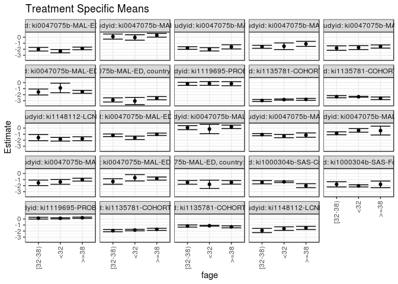

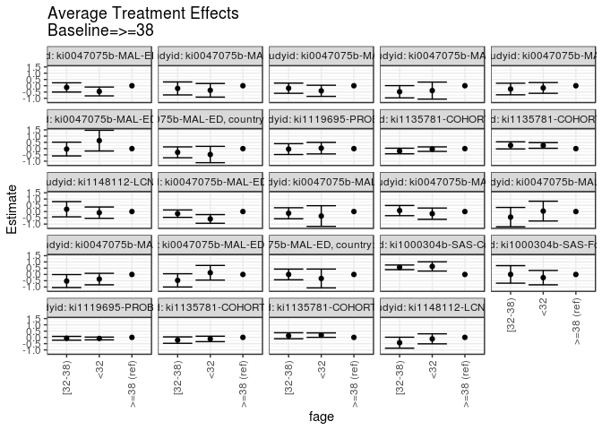

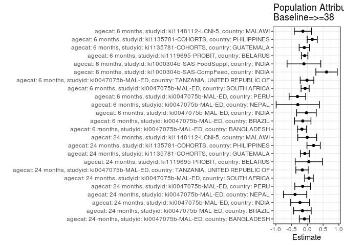

## Results Table

### Parameter: TSM

| agecat | studyid | country | intervention_level | baseline_level | estimate | ci_lower | ci_upper |
| --- | --- | --- | --- | --- | --- | --- | --- |
| 6 months | ki0047075b-MAL-ED | BANGLADESH | >=38 | NA | -1.0251188 | -1.2247229 | -0.8255146 |
| 6 months | ki0047075b-MAL-ED | BANGLADESH | <32 | NA | -1.6133838 | -1.8954300 | -1.3313375 |
| 6 months | ki0047075b-MAL-ED | BANGLADESH | [32-38) | NA | -1.1919486 | -1.4091794 | -0.9747179 |
| 6 months | ki0047075b-MAL-ED | BRAZIL | >=38 | NA | 0.2017918 | -0.0863858 | 0.4899693 |
| 6 months | ki0047075b-MAL-ED | BRAZIL | <32 | NA | -0.1550383 | -0.9199273 | 0.6098508 |
| 6 months | ki0047075b-MAL-ED | BRAZIL | [32-38) | NA | 0.0671775 | -0.2628240 | 0.3971789 |
| 6 months | ki0047075b-MAL-ED | INDIA | >=38 | NA | -1.1604147 | -1.5244036 | -0.7964258 |
| 6 months | ki0047075b-MAL-ED | INDIA | <32 | NA | -1.3295721 | -1.5941084 | -1.0650358 |
| 6 months | ki0047075b-MAL-ED | INDIA | [32-38) | NA | -1.0831533 | -1.2669567 | -0.8993499 |
| 6 months | ki0047075b-MAL-ED | NEPAL | >=38 | NA | -0.4216971 | -1.1539303 | 0.3105361 |
| 6 months | ki0047075b-MAL-ED | NEPAL | <32 | NA | -0.3852201 | -0.6829015 | -0.0875387 |
| 6 months | ki0047075b-MAL-ED | NEPAL | [32-38) | NA | -0.8647740 | -1.1059802 | -0.6235677 |
| 6 months | ki0047075b-MAL-ED | PERU | >=38 | NA | -1.0146629 | -1.2546440 | -0.7746817 |
| 6 months | ki0047075b-MAL-ED | PERU | <32 | NA | -1.3811994 | -1.7734441 | -0.9889548 |
| 6 months | ki0047075b-MAL-ED | PERU | [32-38) | NA | -1.5410462 | -1.9920003 | -1.0900921 |
| 6 months | ki0047075b-MAL-ED | SOUTH AFRICA | >=38 | NA | -0.8373958 | -1.0973701 | -0.5774216 |
| 6 months | ki0047075b-MAL-ED | SOUTH AFRICA | <32 | NA | -0.7000000 | -1.2227635 | -0.1772365 |
| 6 months | ki0047075b-MAL-ED | SOUTH AFRICA | [32-38) | NA | -1.3092708 | -1.7716326 | -0.8469090 |
| 6 months | ki0047075b-MAL-ED | TANZANIA, UNITED REPUBLIC OF | >=38 | NA | -1.4640771 | -1.7575120 | -1.1706422 |
| 6 months | ki0047075b-MAL-ED | TANZANIA, UNITED REPUBLIC OF | <32 | NA | -1.7843226 | -2.4658617 | -1.1027835 |
| 6 months | ki0047075b-MAL-ED | TANZANIA, UNITED REPUBLIC OF | [32-38) | NA | -1.4626077 | -1.7675906 | -1.1576248 |
| 6 months | ki1000304b-SAS-CompFeed | INDIA | >=38 | NA | -2.0099169 | -2.3366410 | -1.6831929 |
| 6 months | ki1000304b-SAS-CompFeed | INDIA | <32 | NA | -1.3676317 | -1.4968526 | -1.2384108 |
| 6 months | ki1000304b-SAS-CompFeed | INDIA | [32-38) | NA | -1.4408091 | -1.7106609 | -1.1709573 |
| 6 months | ki1000304b-SAS-FoodSuppl | INDIA | >=38 | NA | -1.7899345 | -2.3356234 | -1.2442456 |
| 6 months | ki1000304b-SAS-FoodSuppl | INDIA | <32 | NA | -2.0422948 | -2.2211887 | -1.8634009 |
| 6 months | ki1000304b-SAS-FoodSuppl | INDIA | [32-38) | NA | -1.7851309 | -2.2223856 | -1.3478762 |
| 6 months | ki1119695-PROBIT | BELARUS | >=38 | NA | 0.2012605 | 0.0952067 | 0.3073142 |
| 6 months | ki1119695-PROBIT | BELARUS | <32 | NA | 0.1144723 | 0.0186215 | 0.2103231 |
| 6 months | ki1119695-PROBIT | BELARUS | [32-38) | NA | 0.1308627 | -0.0132678 | 0.2749932 |
| 6 months | ki1135781-COHORTS | GUATEMALA | >=38 | NA | -1.7106418 | -1.8890686 | -1.5322151 |
| 6 months | ki1135781-COHORTS | GUATEMALA | <32 | NA | -1.8329693 | -1.9551386 | -1.7108000 |
| 6 months | ki1135781-COHORTS | GUATEMALA | [32-38) | NA | -1.9278007 | -2.1121703 | -1.7434310 |
| 6 months | ki1135781-COHORTS | PHILIPPINES | >=38 | NA | -1.2972035 | -1.4611318 | -1.1332753 |
| 6 months | ki1135781-COHORTS | PHILIPPINES | <32 | NA | -1.1167769 | -1.1853016 | -1.0482521 |
| 6 months | ki1135781-COHORTS | PHILIPPINES | [32-38) | NA | -1.1663506 | -1.3395492 | -0.9931520 |
| 6 months | ki1148112-LCNI-5 | MALAWI | >=38 | NA | -1.4787518 | -1.7392713 | -1.2182322 |
| 6 months | ki1148112-LCNI-5 | MALAWI | <32 | NA | -1.5944445 | -1.8918884 | -1.2970006 |
| 6 months | ki1148112-LCNI-5 | MALAWI | [32-38) | NA | -1.9031306 | -2.2513559 | -1.5549053 |
| 24 months | ki0047075b-MAL-ED | BANGLADESH | >=38 | NA | -1.8643441 | -2.0802922 | -1.6483961 |
| 24 months | ki0047075b-MAL-ED | BANGLADESH | <32 | NA | -2.3217726 | -2.5969495 | -2.0465957 |
| 24 months | ki0047075b-MAL-ED | BANGLADESH | [32-38) | NA | -1.9989910 | -2.2993882 | -1.6985939 |
| 24 months | ki0047075b-MAL-ED | BRAZIL | >=38 | NA | 0.3154190 | 0.0115770 | 0.6192610 |
| 24 months | ki0047075b-MAL-ED | BRAZIL | <32 | NA | -0.0491089 | -0.4962127 | 0.3979948 |
| 24 months | ki0047075b-MAL-ED | BRAZIL | [32-38) | NA | 0.0989463 | -0.3220977 | 0.5199903 |
| 24 months | ki0047075b-MAL-ED | INDIA | >=38 | NA | -1.6018402 | -1.9488001 | -1.2548803 |
| 24 months | ki0047075b-MAL-ED | INDIA | <32 | NA | -2.0080937 | -2.2854820 | -1.7307054 |
| 24 months | ki0047075b-MAL-ED | INDIA | [32-38) | NA | -1.8001176 | -2.0166832 | -1.5835520 |
| 24 months | ki0047075b-MAL-ED | NEPAL | >=38 | NA | -1.1120571 | -1.5287809 | -0.6953332 |
| 24 months | ki0047075b-MAL-ED | NEPAL | <32 | NA | -1.4999801 | -2.0526140 | -0.9473462 |
| 24 months | ki0047075b-MAL-ED | NEPAL | [32-38) | NA | -1.5910710 | -1.8358184 | -1.3463235 |
| 24 months | ki0047075b-MAL-ED | PERU | >=38 | NA | -1.5474204 | -1.8126217 | -1.2822191 |
| 24 months | ki0047075b-MAL-ED | PERU | <32 | NA | -1.7232432 | -2.0532143 | -1.3932721 |
| 24 months | ki0047075b-MAL-ED | PERU | [32-38) | NA | -1.8105425 | -2.1864814 | -1.4346036 |
| 24 months | ki0047075b-MAL-ED | SOUTH AFRICA | >=38 | NA | -1.5213077 | -1.7646345 | -1.2779809 |
| 24 months | ki0047075b-MAL-ED | SOUTH AFRICA | <32 | NA | -0.8812500 | -1.6713902 | -0.0911098 |
| 24 months | ki0047075b-MAL-ED | SOUTH AFRICA | [32-38) | NA | -1.5543750 | -2.0461910 | -1.0625590 |
| 24 months | ki0047075b-MAL-ED | TANZANIA, UNITED REPUBLIC OF | >=38 | NA | -2.5721934 | -2.8343668 | -2.3100200 |
| 24 months | ki0047075b-MAL-ED | TANZANIA, UNITED REPUBLIC OF | <32 | NA | -3.0421465 | -3.6379999 | -2.4462930 |
| 24 months | ki0047075b-MAL-ED | TANZANIA, UNITED REPUBLIC OF | [32-38) | NA | -2.8660540 | -3.2099669 | -2.5221411 |
| 24 months | ki1119695-PROBIT | BELARUS | >=38 | NA | -0.1728035 | -0.5164507 | 0.1708437 |
| 24 months | ki1119695-PROBIT | BELARUS | <32 | NA | -0.1343948 | -0.4511776 | 0.1823881 |
| 24 months | ki1119695-PROBIT | BELARUS | [32-38) | NA | -0.2093914 | -0.4634826 | 0.0446998 |
| 24 months | ki1135781-COHORTS | GUATEMALA | >=38 | NA | -2.7707681 | -2.9224071 | -2.6191291 |
| 24 months | ki1135781-COHORTS | GUATEMALA | <32 | NA | -2.8084136 | -2.9046039 | -2.7122233 |
| 24 months | ki1135781-COHORTS | GUATEMALA | [32-38) | NA | -2.9581583 | -3.1220459 | -2.7942708 |
| 24 months | ki1135781-COHORTS | PHILIPPINES | >=38 | NA | -2.5945946 | -2.8111048 | -2.3780844 |
| 24 months | ki1135781-COHORTS | PHILIPPINES | <32 | NA | -2.3401134 | -2.4076082 | -2.2726185 |
| 24 months | ki1135781-COHORTS | PHILIPPINES | [32-38) | NA | -2.3330998 | -2.5155038 | -2.1506958 |
| 24 months | ki1148112-LCNI-5 | MALAWI | >=38 | NA | -1.7645633 | -2.0922751 | -1.4368516 |
| 24 months | ki1148112-LCNI-5 | MALAWI | <32 | NA | -1.8525760 | -2.1589011 | -1.5462509 |
| 24 months | ki1148112-LCNI-5 | MALAWI | [32-38) | NA | -1.5788941 | -2.0873268 | -1.0704615 |

### Parameter: E(Y)

| agecat | studyid | country | intervention_level | baseline_level | estimate | ci_lower | ci_upper |
| --- | --- | --- | --- | --- | --- | --- | --- |
| 6 months | ki0047075b-MAL-ED | BANGLADESH | NA | NA | -1.1979000 | -1.3314769 | -1.0643231 |
| 6 months | ki0047075b-MAL-ED | BRAZIL | NA | NA | 0.0554008 | -0.1690575 | 0.2798592 |
| 6 months | ki0047075b-MAL-ED | INDIA | NA | NA | -1.1894617 | -1.3346428 | -1.0442806 |
| 6 months | ki0047075b-MAL-ED | NEPAL | NA | NA | -0.7256962 | -0.9111717 | -0.5402207 |
| 6 months | ki0047075b-MAL-ED | PERU | NA | NA | -1.3300201 | -1.5375346 | -1.1225056 |
| 6 months | ki0047075b-MAL-ED | SOUTH AFRICA | NA | NA | -0.9083333 | -1.1234247 | -0.6932420 |
| 6 months | ki0047075b-MAL-ED | TANZANIA, UNITED REPUBLIC OF | NA | NA | -1.4744833 | -1.6639782 | -1.2849884 |
| 6 months | ki1000304b-SAS-CompFeed | INDIA | NA | NA | -1.4006377 | -1.4802862 | -1.3209891 |
| 6 months | ki1000304b-SAS-FoodSuppl | INDIA | NA | NA | -1.8986842 | -2.0118892 | -1.7854792 |
| 6 months | ki1119695-PROBIT | BELARUS | NA | NA | 0.1166130 | 0.0230160 | 0.2102100 |
| 6 months | ki1135781-COHORTS | GUATEMALA | NA | NA | -1.8068353 | -1.8758487 | -1.7378219 |
| 6 months | ki1135781-COHORTS | PHILIPPINES | NA | NA | -1.1421265 | -1.1845116 | -1.0997415 |
| 6 months | ki1148112-LCNI-5 | MALAWI | NA | NA | -1.6211321 | -1.8052501 | -1.4370141 |
| 24 months | ki0047075b-MAL-ED | BANGLADESH | NA | NA | -1.9567550 | -2.0984173 | -1.8150926 |
| 24 months | ki0047075b-MAL-ED | BRAZIL | NA | NA | 0.1588608 | -0.0651474 | 0.3828689 |
| 24 months | ki0047075b-MAL-ED | INDIA | NA | NA | -1.8373292 | -1.9909581 | -1.6837003 |
| 24 months | ki0047075b-MAL-ED | NEPAL | NA | NA | -1.5030380 | -1.6956243 | -1.3104516 |
| 24 months | ki0047075b-MAL-ED | PERU | NA | NA | -1.6960127 | -1.8853995 | -1.5066258 |
| 24 months | ki0047075b-MAL-ED | SOUTH AFRICA | NA | NA | -1.4697191 | -1.6840618 | -1.2553764 |
| 24 months | ki0047075b-MAL-ED | TANZANIA, UNITED REPUBLIC OF | NA | NA | -2.7318500 | -2.9253580 | -2.5383420 |
| 24 months | ki1119695-PROBIT | BELARUS | NA | NA | -0.1254844 | -0.4225624 | 0.1715937 |
| 24 months | ki1135781-COHORTS | GUATEMALA | NA | NA | -2.8513770 | -2.9170436 | -2.7857104 |
| 24 months | ki1135781-COHORTS | PHILIPPINES | NA | NA | -2.3958878 | -2.4412250 | -2.3505506 |
| 24 months | ki1148112-LCNI-5 | MALAWI | NA | NA | -1.7689189 | -1.9714091 | -1.5664287 |

### Parameter: ATE

| agecat | studyid | country | intervention_level | baseline_level | estimate | ci_lower | ci_upper |
| --- | --- | --- | --- | --- | --- | --- | --- |
| 6 months | ki0047075b-MAL-ED | BANGLADESH | >=38 | >=38 | 0.0000000 | 0.0000000 | 0.0000000 |
| 6 months | ki0047075b-MAL-ED | BANGLADESH | <32 | >=38 | -0.5882650 | -0.9346962 | -0.2418338 |
| 6 months | ki0047075b-MAL-ED | BANGLADESH | [32-38) | >=38 | -0.1668299 | -0.4615795 | 0.1279198 |
| 6 months | ki0047075b-MAL-ED | BRAZIL | >=38 | >=38 | 0.0000000 | 0.0000000 | 0.0000000 |
| 6 months | ki0047075b-MAL-ED | BRAZIL | <32 | >=38 | -0.3568300 | -1.1815542 | 0.4678941 |
| 6 months | ki0047075b-MAL-ED | BRAZIL | [32-38) | >=38 | -0.1346143 | -0.5745789 | 0.3053503 |
| 6 months | ki0047075b-MAL-ED | INDIA | >=38 | >=38 | 0.0000000 | 0.0000000 | 0.0000000 |
| 6 months | ki0047075b-MAL-ED | INDIA | <32 | >=38 | -0.1691574 | -0.6174044 | 0.2790896 |
| 6 months | ki0047075b-MAL-ED | INDIA | [32-38) | >=38 | 0.0772614 | -0.3287018 | 0.4832246 |
| 6 months | ki0047075b-MAL-ED | NEPAL | >=38 | >=38 | 0.0000000 | 0.0000000 | 0.0000000 |
| 6 months | ki0047075b-MAL-ED | NEPAL | <32 | >=38 | 0.0364770 | -0.7536377 | 0.8265917 |
| 6 months | ki0047075b-MAL-ED | NEPAL | [32-38) | >=38 | -0.4430768 | -1.2137679 | 0.3276142 |
| 6 months | ki0047075b-MAL-ED | PERU | >=38 | >=38 | 0.0000000 | 0.0000000 | 0.0000000 |
| 6 months | ki0047075b-MAL-ED | PERU | <32 | >=38 | -0.3665365 | -0.8257872 | 0.0927141 |
| 6 months | ki0047075b-MAL-ED | PERU | [32-38) | >=38 | -0.5263833 | -1.0455103 | -0.0072563 |
| 6 months | ki0047075b-MAL-ED | SOUTH AFRICA | >=38 | >=38 | 0.0000000 | 0.0000000 | 0.0000000 |
| 6 months | ki0047075b-MAL-ED | SOUTH AFRICA | <32 | >=38 | 0.1373958 | -0.4464434 | 0.7212351 |
| 6 months | ki0047075b-MAL-ED | SOUTH AFRICA | [32-38) | >=38 | -0.4718750 | -1.0023136 | 0.0585636 |
| 6 months | ki0047075b-MAL-ED | TANZANIA, UNITED REPUBLIC OF | >=38 | >=38 | 0.0000000 | 0.0000000 | 0.0000000 |
| 6 months | ki0047075b-MAL-ED | TANZANIA, UNITED REPUBLIC OF | <32 | >=38 | -0.3202455 | -1.0702694 | 0.4297784 |
| 6 months | ki0047075b-MAL-ED | TANZANIA, UNITED REPUBLIC OF | [32-38) | >=38 | 0.0014694 | -0.4258568 | 0.4287957 |
| 6 months | ki1000304b-SAS-CompFeed | INDIA | >=38 | >=38 | 0.0000000 | 0.0000000 | 0.0000000 |
| 6 months | ki1000304b-SAS-CompFeed | INDIA | <32 | >=38 | 0.6422852 | 0.2730951 | 1.0114753 |
| 6 months | ki1000304b-SAS-CompFeed | INDIA | [32-38) | >=38 | 0.5691078 | 0.3848979 | 0.7533177 |
| 6 months | ki1000304b-SAS-FoodSuppl | INDIA | >=38 | >=38 | 0.0000000 | 0.0000000 | 0.0000000 |
| 6 months | ki1000304b-SAS-FoodSuppl | INDIA | <32 | >=38 | -0.2523603 | -0.8262460 | 0.3215254 |
| 6 months | ki1000304b-SAS-FoodSuppl | INDIA | [32-38) | >=38 | 0.0048036 | -0.6945183 | 0.7041256 |
| 6 months | ki1119695-PROBIT | BELARUS | >=38 | >=38 | 0.0000000 | 0.0000000 | 0.0000000 |
| 6 months | ki1119695-PROBIT | BELARUS | <32 | >=38 | -0.0867882 | -0.1972155 | 0.0236392 |
| 6 months | ki1119695-PROBIT | BELARUS | [32-38) | >=38 | -0.0703978 | -0.2197627 | 0.0789671 |
| 6 months | ki1135781-COHORTS | GUATEMALA | >=38 | >=38 | 0.0000000 | 0.0000000 | 0.0000000 |
| 6 months | ki1135781-COHORTS | GUATEMALA | <32 | >=38 | -0.1223275 | -0.3384519 | 0.0937969 |
| 6 months | ki1135781-COHORTS | GUATEMALA | [32-38) | >=38 | -0.2171589 | -0.4739712 | 0.0396535 |
| 6 months | ki1135781-COHORTS | PHILIPPINES | >=38 | >=38 | 0.0000000 | 0.0000000 | 0.0000000 |
| 6 months | ki1135781-COHORTS | PHILIPPINES | <32 | >=38 | 0.1804267 | 0.0027013 | 0.3581521 |
| 6 months | ki1135781-COHORTS | PHILIPPINES | [32-38) | >=38 | 0.1308530 | -0.1077308 | 0.3694367 |
| 6 months | ki1148112-LCNI-5 | MALAWI | >=38 | >=38 | 0.0000000 | 0.0000000 | 0.0000000 |
| 6 months | ki1148112-LCNI-5 | MALAWI | <32 | >=38 | -0.1156927 | -0.5170749 | 0.2856894 |
| 6 months | ki1148112-LCNI-5 | MALAWI | [32-38) | >=38 | -0.4243789 | -0.8609665 | 0.0122088 |
| 24 months | ki0047075b-MAL-ED | BANGLADESH | >=38 | >=38 | 0.0000000 | 0.0000000 | 0.0000000 |
| 24 months | ki0047075b-MAL-ED | BANGLADESH | <32 | >=38 | -0.4574285 | -0.8092242 | -0.1056327 |
| 24 months | ki0047075b-MAL-ED | BANGLADESH | [32-38) | >=38 | -0.1346469 | -0.5031607 | 0.2338670 |
| 24 months | ki0047075b-MAL-ED | BRAZIL | >=38 | >=38 | 0.0000000 | 0.0000000 | 0.0000000 |
| 24 months | ki0047075b-MAL-ED | BRAZIL | <32 | >=38 | -0.3645279 | -0.9076525 | 0.1785967 |
| 24 months | ki0047075b-MAL-ED | BRAZIL | [32-38) | >=38 | -0.2164727 | -0.7355549 | 0.3026095 |
| 24 months | ki0047075b-MAL-ED | INDIA | >=38 | >=38 | 0.0000000 | 0.0000000 | 0.0000000 |
| 24 months | ki0047075b-MAL-ED | INDIA | <32 | >=38 | -0.4062535 | -0.8492804 | 0.0367733 |
| 24 months | ki0047075b-MAL-ED | INDIA | [32-38) | >=38 | -0.1982774 | -0.6041541 | 0.2075993 |
| 24 months | ki0047075b-MAL-ED | NEPAL | >=38 | >=38 | 0.0000000 | 0.0000000 | 0.0000000 |
| 24 months | ki0047075b-MAL-ED | NEPAL | <32 | >=38 | -0.3879230 | -1.0669748 | 0.2911288 |
| 24 months | ki0047075b-MAL-ED | NEPAL | [32-38) | >=38 | -0.4790139 | -0.9677108 | 0.0096830 |
| 24 months | ki0047075b-MAL-ED | PERU | >=38 | >=38 | 0.0000000 | 0.0000000 | 0.0000000 |
| 24 months | ki0047075b-MAL-ED | PERU | <32 | >=38 | -0.1758228 | -0.6049152 | 0.2532696 |
| 24 months | ki0047075b-MAL-ED | PERU | [32-38) | >=38 | -0.2631221 | -0.7253785 | 0.1991342 |
| 24 months | ki0047075b-MAL-ED | SOUTH AFRICA | >=38 | >=38 | 0.0000000 | 0.0000000 | 0.0000000 |
| 24 months | ki0047075b-MAL-ED | SOUTH AFRICA | <32 | >=38 | 0.6400577 | -0.1867007 | 1.4668161 |
| 24 months | ki0047075b-MAL-ED | SOUTH AFRICA | [32-38) | >=38 | -0.0330673 | -0.5817848 | 0.5156502 |
| 24 months | ki0047075b-MAL-ED | TANZANIA, UNITED REPUBLIC OF | >=38 | >=38 | 0.0000000 | 0.0000000 | 0.0000000 |
| 24 months | ki0047075b-MAL-ED | TANZANIA, UNITED REPUBLIC OF | <32 | >=38 | -0.4699531 | -1.1234676 | 0.1835615 |
| 24 months | ki0047075b-MAL-ED | TANZANIA, UNITED REPUBLIC OF | [32-38) | >=38 | -0.2938606 | -0.7284402 | 0.1407191 |
| 24 months | ki1119695-PROBIT | BELARUS | >=38 | >=38 | 0.0000000 | 0.0000000 | 0.0000000 |
| 24 months | ki1119695-PROBIT | BELARUS | <32 | >=38 | 0.0384088 | -0.4227351 | 0.4995526 |
| 24 months | ki1119695-PROBIT | BELARUS | [32-38) | >=38 | -0.0365879 | -0.4702778 | 0.3971020 |
| 24 months | ki1135781-COHORTS | GUATEMALA | >=38 | >=38 | 0.0000000 | 0.0000000 | 0.0000000 |
| 24 months | ki1135781-COHORTS | GUATEMALA | <32 | >=38 | -0.0376456 | -0.2157900 | 0.1404989 |
| 24 months | ki1135781-COHORTS | GUATEMALA | [32-38) | >=38 | -0.1873903 | -0.4096843 | 0.0349038 |
| 24 months | ki1135781-COHORTS | PHILIPPINES | >=38 | >=38 | 0.0000000 | 0.0000000 | 0.0000000 |
| 24 months | ki1135781-COHORTS | PHILIPPINES | <32 | >=38 | 0.2544812 | 0.0276475 | 0.4813150 |
| 24 months | ki1135781-COHORTS | PHILIPPINES | [32-38) | >=38 | 0.2614948 | -0.0217177 | 0.5447074 |
| 24 months | ki1148112-LCNI-5 | MALAWI | >=38 | >=38 | 0.0000000 | 0.0000000 | 0.0000000 |
| 24 months | ki1148112-LCNI-5 | MALAWI | <32 | >=38 | -0.0880127 | -0.5393650 | 0.3633397 |
| 24 months | ki1148112-LCNI-5 | MALAWI | [32-38) | >=38 | 0.1856692 | -0.4216095 | 0.7929479 |

### Parameter: PAR

| agecat | studyid | country | intervention_level | baseline_level | estimate | ci_lower | ci_upper |
| --- | --- | --- | --- | --- | --- | --- | --- |
| 6 months | ki0047075b-MAL-ED | BANGLADESH | >=38 | NA | -0.1727812 | -0.3193422 | -0.0262203 |
| 6 months | ki0047075b-MAL-ED | BRAZIL | >=38 | NA | -0.1463909 | -0.4072342 | 0.1144524 |
| 6 months | ki0047075b-MAL-ED | INDIA | >=38 | NA | -0.0290470 | -0.3406595 | 0.2825655 |
| 6 months | ki0047075b-MAL-ED | NEPAL | >=38 | NA | -0.3039991 | -0.9906474 | 0.3826492 |
| 6 months | ki0047075b-MAL-ED | PERU | >=38 | NA | -0.3153572 | -0.5793100 | -0.0514044 |
| 6 months | ki0047075b-MAL-ED | SOUTH AFRICA | >=38 | NA | -0.0709375 | -0.1999633 | 0.0580883 |
| 6 months | ki0047075b-MAL-ED | TANZANIA, UNITED REPUBLIC OF | >=38 | NA | -0.0104062 | -0.2267957 | 0.2059832 |
| 6 months | ki1000304b-SAS-CompFeed | INDIA | >=38 | NA | 0.6092793 | 0.2701707 | 0.9483878 |
| 6 months | ki1000304b-SAS-FoodSuppl | INDIA | >=38 | NA | -0.1087497 | -0.6439307 | 0.4264313 |
| 6 months | ki1119695-PROBIT | BELARUS | >=38 | NA | -0.0846475 | -0.1866432 | 0.0173483 |
| 6 months | ki1135781-COHORTS | GUATEMALA | >=38 | NA | -0.0961935 | -0.2608391 | 0.0684522 |
| 6 months | ki1135781-COHORTS | PHILIPPINES | >=38 | NA | 0.1550770 | -0.0052440 | 0.3153981 |
| 6 months | ki1148112-LCNI-5 | MALAWI | >=38 | NA | -0.1423803 | -0.4157789 | 0.1310182 |
| 24 months | ki0047075b-MAL-ED | BANGLADESH | >=38 | NA | -0.0924108 | -0.2573256 | 0.0725039 |
| 24 months | ki0047075b-MAL-ED | BRAZIL | >=38 | NA | -0.1565582 | -0.4353109 | 0.1221945 |
| 24 months | ki0047075b-MAL-ED | INDIA | >=38 | NA | -0.2354890 | -0.5416975 | 0.0707195 |
| 24 months | ki0047075b-MAL-ED | NEPAL | >=38 | NA | -0.3909809 | -0.7599310 | -0.0220308 |
| 24 months | ki0047075b-MAL-ED | PERU | >=38 | NA | -0.1485923 | -0.3980980 | 0.1009134 |
| 24 months | ki0047075b-MAL-ED | SOUTH AFRICA | >=38 | NA | 0.0515886 | -0.0850395 | 0.1882167 |
| 24 months | ki0047075b-MAL-ED | TANZANIA, UNITED REPUBLIC OF | >=38 | NA | -0.1596566 | -0.3657666 | 0.0464534 |
| 24 months | ki1119695-PROBIT | BELARUS | >=38 | NA | 0.0473192 | -0.3866819 | 0.4813203 |
| 24 months | ki1135781-COHORTS | GUATEMALA | >=38 | NA | -0.0806089 | -0.2227232 | 0.0615054 |
| 24 months | ki1135781-COHORTS | PHILIPPINES | >=38 | NA | 0.1987068 | -0.0129863 | 0.4103999 |
| 24 months | ki1148112-LCNI-5 | MALAWI | >=38 | NA | -0.0043556 | -0.3041238 | 0.2954126 |